# PW5

PINPIN Pierrick

2022-10-12

# *Regression Tree Model*

## Question 1

```r
library("MASS")
library("caTools")

set.seed(1)

sample_size <- sample(1:nrow(Boston), size= round(0.5*nrow(Boston)), replace= FALSE)

training_set <- Boston[sample_size,]
test_set <- Boston[-sample_size,]

dim(training_set)
```

```
## [1] 253  14
```

```r
dim(test_set)
```

```
## [1] 253  14
```

## Question 2

```r
library("rpart")

Boston_tree <- rpart(formula= medv~., data= training_set, method  = "anova")
```

## Question 3

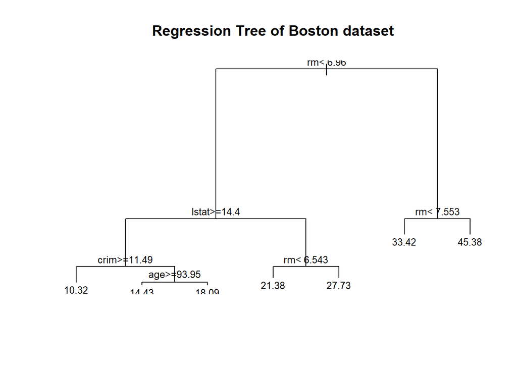

```r
plot(Boston_tree)
text(Boston_tree,pretty=0,cex=0.8)
title(main = "Regression Tree of Boston dataset")
```

## Question 4

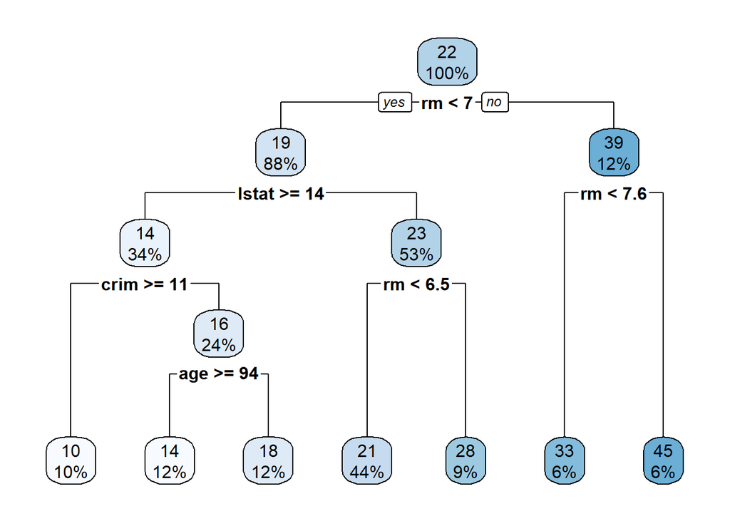

```r
library("rpart.plot")

rpart.plot(Boston_tree)
```

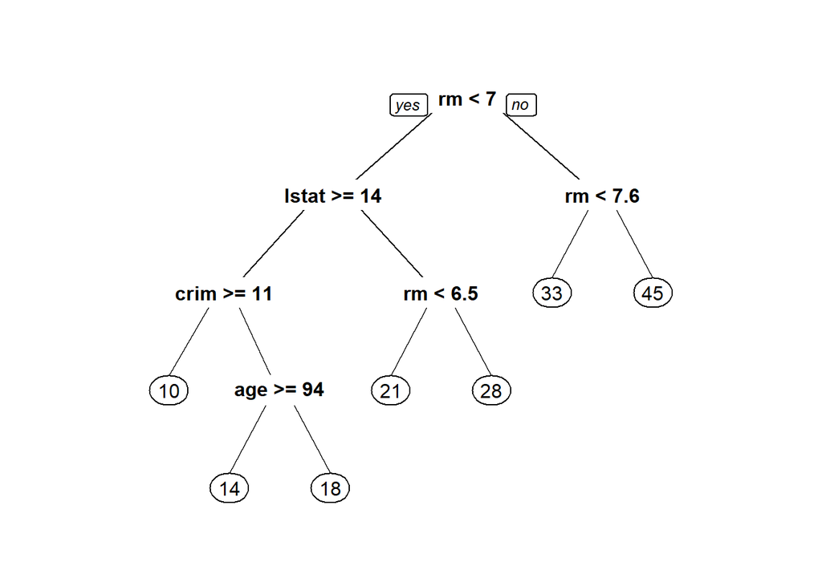

```r
prp(Boston_tree)
```

##Question 5

```r
summary(Boston_tree)
```

```
## Call:
## rpart(formula = medv ~ ., data = training_set, method = "anova")
##   n= 253
##
##           CP nsplit rel error    xerror       xstd
## 1 0.55145333      0 1.0000000 1.0024582 0.12627136
## 2 0.17610053      1 0.4485467 0.4845589 0.04276338
## 3 0.05689532      2 0.2724461 0.3031982 0.03060864
## 4 0.04093613      3 0.2155508 0.2760398 0.02989290
## 5 0.03276814      4 0.1746147 0.2387489 0.02848397
## 6 0.01048773      5 0.1418465 0.2169243 0.02729011
## 7 0.01000000      6 0.1313588 0.2177695 0.02733643
##
## Variable importance
##      rm   lstat    crim     dis     age     nox      zn   indus     tax ptratio
##      34      23       9       7       6       5       4       4       4       4
##
## Node number 1: 253 observations,    complexity param=0.5514533
##   mean=21.78656, MSE=76.86907
##   left son=2 (222 obs) right son=3 (31 obs)
##   Primary splits:
##       rm      < 6.9595   to the left,  improve=0.5514533, (0 missing)
##       lstat   < 8.13     to the right, improve=0.4710854, (0 missing)
##       ptratio < 19.65    to the right, improve=0.2687694, (0 missing)
##       indus   < 6.66     to the right, improve=0.2552622, (0 missing)
##       nox     < 0.5125   to the right, improve=0.2357242, (0 missing)
##   Surrogate splits:
##       lstat   < 4.6      to the right, agree=0.925, adj=0.387, (0 split)
##       indus   < 1.605    to the right, agree=0.893, adj=0.129, (0 split)
##       ptratio < 14.15    to the right, agree=0.893, adj=0.129, (0 split)
##       zn      < 86.25    to the left,  agree=0.889, adj=0.097, (0 split)
##       crim    < 0.01958  to the right, agree=0.885, adj=0.065, (0 split)
##
## Node number 2: 222 observations,    complexity param=0.1761005
##   mean=19.3536, MSE=30.60492
##   left son=4 (87 obs) right son=5 (135 obs)
##   Primary splits:
##       lstat < 14.405   to the right, improve=0.5040674, (0 missing)
##       crim  < 6.108565 to the right, improve=0.3586261, (0 missing)
##       dis   < 2.23995  to the left,  improve=0.3565564, (0 missing)
```

[output cut: 75 more lines]

```
##       nox   < 0.597    to the right, agree=0.721, adj=0.433, (0 split)
##       lstat < 17.995   to the right, agree=0.721, adj=0.433, (0 split)
##       crim  < 0.308165 to the right, agree=0.705, adj=0.400, (0 split)
##
## Node number 10: 111 observations
##   mean=21.37748, MSE=6.875078
##
## Node number 11: 24 observations
##   mean=27.72917, MSE=10.68623
##
## Node number 18: 31 observations
##   mean=14.42903, MSE=5.294318
##
## Node number 19: 30 observations
##   mean=18.08667, MSE=8.190489
```

```r
printcp(Boston_tree)
```

```
##
## Regression tree:
## rpart(formula = medv ~ ., data = training_set, method = "anova")
##
## Variables actually used in tree construction:
## [1] age   crim  lstat rm
##
## Root node error: 19448/253 = 76.869
##
## n= 253
##
##         CP nsplit rel error  xerror     xstd
## 1 0.551453      0   1.00000 1.00246 0.126271
## 2 0.176101      1   0.44855 0.48456 0.042763
## 3 0.056895      2   0.27245 0.30320 0.030609
## 4 0.040936      3   0.21555 0.27604 0.029893
## 5 0.032768      4   0.17461 0.23875 0.028484
## 6 0.010488      5   0.14185 0.21692 0.027290
## 7 0.010000      6   0.13136 0.21777 0.027336
```

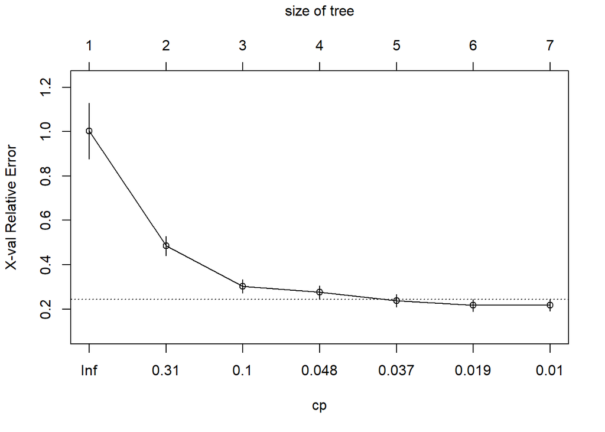

```r
plotcp(Boston_tree)
```

>As a rule of thumb, it is best to prune a decision tree using the cp of smallest tree that is within one standard deviation of the tree with the smallest xerror. In this example, the best xerror is:

> Let’s find the indew of the the minimum xerror:

```r
best_index <- which.min(Boston_tree$cptable[,"xerror"])
best_index
```

```
## 6
## 6
```

> In this example, the smallest xerror is:

```r
Boston_tree$cptable[best_index,"xerror"]
```

```
## [1] 0.2169243
```

> The standart deviation is:

```r
Boston_tree$cptable[best_index,"xstd"]
```

```
## [1] 0.02729011
```

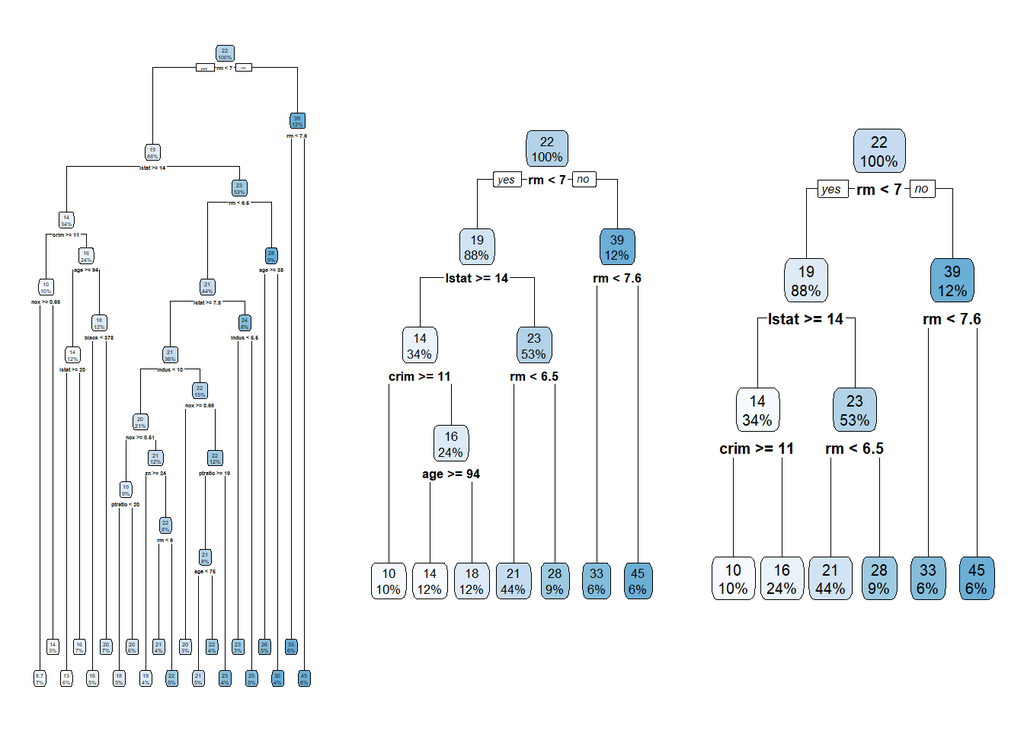

```r
par(mfrow=c(1,3))

Boston_tree <- rpart(medv ~ ., data = training_set, cp=0)
rpart.plot(Boston_tree)

Boston_tree <- rpart(medv ~ ., data = training_set) #cp = 0.01
rpart.plot(Boston_tree)

Boston_tree <- rpart(medv ~ ., data = training_set, cp= 0.010488)
rpart.plot(Boston_tree)
```

## Question 6

```r
RMSE <- function(vect1, vect2){
  rmse <- sqrt(mean((vect1 - vect2)^2))
}
```

## Question 7

```r
pre <- predict(Boston_tree, test_set)
pre
```

```
##        2        3        4        5        6        7        8        9
## 21.37748 33.42500 33.42500 33.42500 21.37748 21.37748 16.22787 16.22787
##       10       11       12       17       18       21       23       26
## 16.22787 16.22787 21.37748 21.37748 16.22787 16.22787 16.22787 16.22787
##       30       32       34       38       46       47       52       54
## 27.72917 21.37748 16.22787 21.37748 21.37748 21.37748 21.37748 21.37748
##       55       56       57       58       59       63       66       67
## 16.22787 33.42500 21.37748 27.72917 21.37748 21.37748 21.37748 21.37748
##       68       69       71       74       76       80       81       82
## 21.37748 21.37748 21.37748 21.37748 21.37748 21.37748 27.72917 27.72917
##       83       87       88       90       91       94       95       96
## 21.37748 21.37748 21.37748 33.42500 21.37748 21.37748 21.37748 27.72917
##       97       99      100      101      106      109      112      114
## 21.37748 45.38000 33.42500 27.72917 16.22787 21.37748 27.72917 16.22787
##      115      119      120      123      125      128      131      134
## 21.37748 16.22787 21.37748 16.22787 16.22787 16.22787 21.37748 16.22787
##      136      137      139      142      144      146      147      150
## 16.22787 16.22787 16.22787 16.22787 16.22787 16.22787 16.22787 16.22787
##      151      154      155      156      157      158      159      161
## 21.37748 16.22787 16.22787 16.22787 16.22787 27.72917 21.37748 21.37748
##      162      164      166      169      171      173      175      177
## 33.42500 45.38000 21.37748 21.37748 16.22787 16.22787 21.37748 21.37748
##      178      179      180      182      183      184      186      188
## 21.37748 27.72917 33.42500 21.37748 33.42500 27.72917 21.37748 27.72917
##      189      190      191      192      195      196      197      199
## 27.72917 33.42500 27.72917 27.72917 27.72917 45.38000 33.42500 33.42500
##      200      201      203      205      208      209      210      211
## 33.42500 33.42500 45.38000 45.38000 16.22787 16.22787 16.22787 16.22787
##      215      216      220      222      223      226      227      228
## 16.22787 21.37748 21.37748 16.22787 27.72917 45.38000 45.38000 33.42500
##      232      235      236      238      240      243      244      245
## 33.42500 27.72917 21.37748 33.42500 27.72917 21.37748 21.37748 21.37748
##      250      251      253      256      257      258      259      260
## 27.72917 21.37748 27.72917 21.37748 33.42500 45.38000 33.42500 27.72917
##      261      262      264      266      267      268      269      272
## 33.42500 33.42500 33.42500 21.37748 33.42500 45.38000 33.42500 21.37748
##      276      278      283      288      291      292      294      301
## 27.72917 27.72917 45.38000 21.37748 27.72917 33.42500 21.37748 27.72917
##      302      303      308      309      310      311      312      314
## 27.72917 21.37748 27.72917 27.72917 21.37748 21.37748 21.37748 21.37748
```

[output cut: 9 more lines]

```
## 10.31538 10.31538 33.42500 16.22787 16.22787 10.31538 10.31538 10.31538
##      388      393      394      397      398      400      403      407
## 10.31538 10.31538 16.22787 16.22787 16.22787 16.22787 16.22787 10.31538
##      409      410      411      417      424      425      426      429
## 16.22787 10.31538 21.37748 16.22787 16.22787 16.22787 10.31538 16.22787
##      430      432      439      440      441      447      448      451
## 16.22787 16.22787 10.31538 16.22787 10.31538 16.22787 16.22787 16.22787
##      452      453      454      455      456      457      460      462
## 16.22787 16.22787 33.42500 16.22787 16.22787 16.22787 16.22787 16.22787
##      468      469      470      472      474      475      477      479
## 16.22787 10.31538 10.31538 21.37748 33.42500 16.22787 16.22787 16.22787
##      482      486      487      489      491      493      494      495
## 27.72917 21.37748 16.22787 16.22787 16.22787 21.37748 21.37748 21.37748
##      497      499      502      504      506
## 16.22787 21.37748 27.72917 33.42500 21.37748
```

```r
trmse <- RMSE(test_set$medv, pre)
trmse
```

```
## [1] 5.929957
```

# *Linear Regression Model*

## Question 8

```r
lmodel <- glm(medv~., data= training_set)

lpre <- predict(lmodel, test_set )

lrmse <- RMSE(test_set$medv, lpre)
lrmse
```

```
## [1] 5.182783
```

> We see that the rmse of the linear regression model is smaller than that found with the regression tree. So, we can conclude that: the linear regression model predicts the data better than the regression tree.

## Question 9

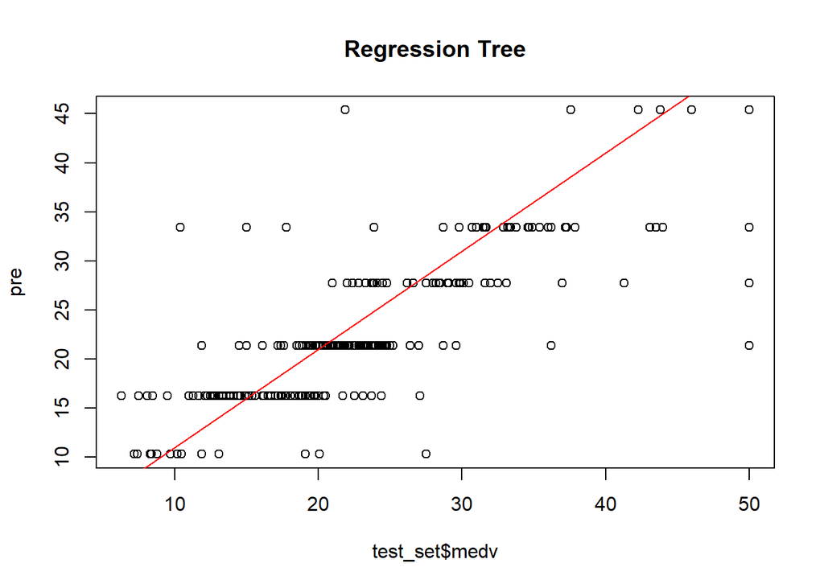

```r
plot(test_set$medv, pre, main= "Regression Tree")
abline(1, 1, col= 'red')
```

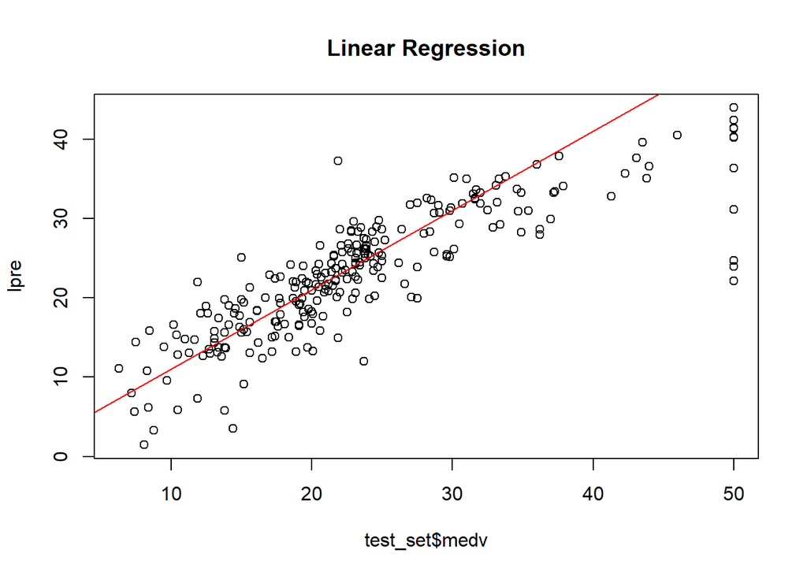

```r
plot(test_set$medv, lpre, main= "Linear Regression")
abline(1, 1, col= 'red')
```

>We can visually see that, there are more points near the line of equation y=x with the linear regression model than the one with the regression tree.

# *Bagging Model*

## Question 10 & Question 11

```r
library("ipred")

bmodel <- bagging(medv~., training_set)

summary(bmodel)
```

```
##        Length Class      Mode
## y      253    -none-     numeric
## X       13    data.frame list
## mtrees  25    -none-     list
## OOB      1    -none-     logical
## comb     1    -none-     logical
## call     3    -none-     call
```

## Question 11

```r
bpre <- predict(bmodel, test_set)

brmse <- RMSE(bpre, test_set$medv)
brmse
```

```
## [1] 5.285633
```

> We can see that the RMSE of the Bagged Model is lower than the Regression Tree Model but higher than the Linear Regression Model.

# *Random Forest*

## Question 12

```r
library("randomForest")
set.seed(123)
rfmodel <- randomForest(medv~., training_set)

rfpre <- predict(rfmodel, test_set)

rfrmse <- RMSE(rfpre, test_set$medv)
rfrmse
```

```
## [1] 4.361607
```

## Question 13

```r
importance(rfmodel)
```

```
##         IncNodePurity
## crim        1290.3166
## zn           216.0298
## indus        818.3568
## chas          56.9066
## nox         1137.0880
## rm          6476.5746
## age          665.9799
## dis          863.4804
## rad          157.3895
## tax          698.9211
## ptratio     1181.8354
## black        314.8660
## lstat       5230.0039
```

> In order, the most important predictors are:

```r
imp <- as.data.frame(importance(rfmodel))
imp <- data.frame(Variables= row.names(imp), IncNodePurity= imp$IncNodePurity)
imp[order(imp$IncNodePurity, decreasing = TRUE),]
```

```
##    Variables IncNodePurity
## 6         rm     6476.5746
## 13     lstat     5230.0039
## 1       crim     1290.3166
## 11   ptratio     1181.8354
## 5        nox     1137.0880
## 8        dis      863.4804
## 3      indus      818.3568
## 10       tax      698.9211
## 7        age      665.9799
## 12     black      314.8660
## 2         zn      216.0298
## 9        rad      157.3895
## 4       chas       56.9066
```

> rm, lstat, crim, ptratio, nox, dis, indus, tax, age, black, zn, rad and chas

> We foud the three most important variables in the last models.

## Question 14

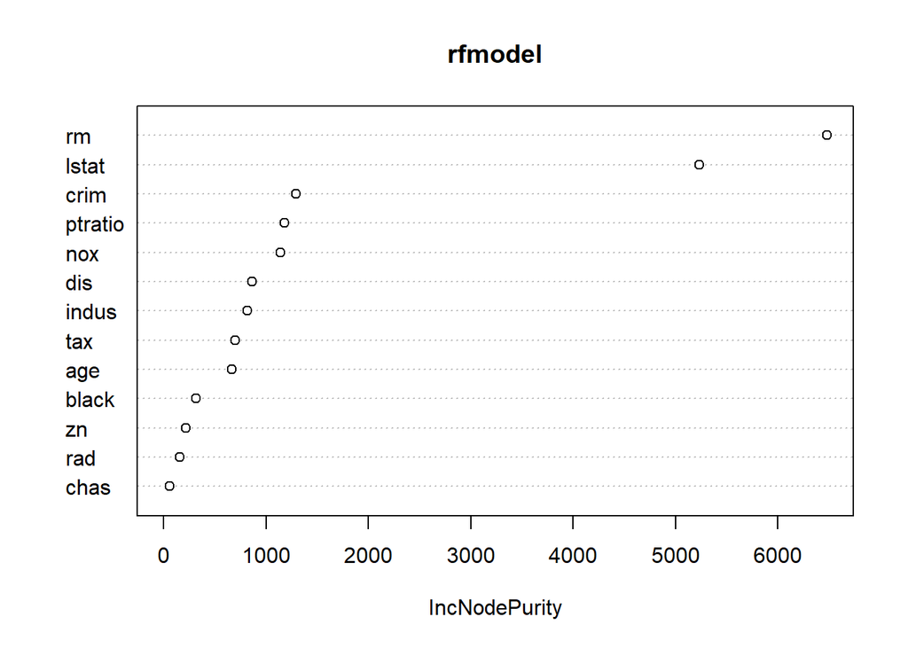

```r
varImpPlot(rfmodel)
```

>This graph confirms that rm, lstat and crim are the most important variables.

# *Boosted Model*

## Question 15

```r
library("gbm")
set.seed(123)
boomodel <- gbm(medv~., data= training_set, distribution= "gaussian", n.trees=500)

boopre <- predict(boomodel, test_set)
```

```
## Using 500 trees...
```

```r
boormse <- RMSE(boopre, test_set$medv)
boormse
```

```
## [1] 4.407787
```

> We can conclude that the Random Forest Model stays the best model to predict the data. Boosted Model still has a good performance.

## Question 16

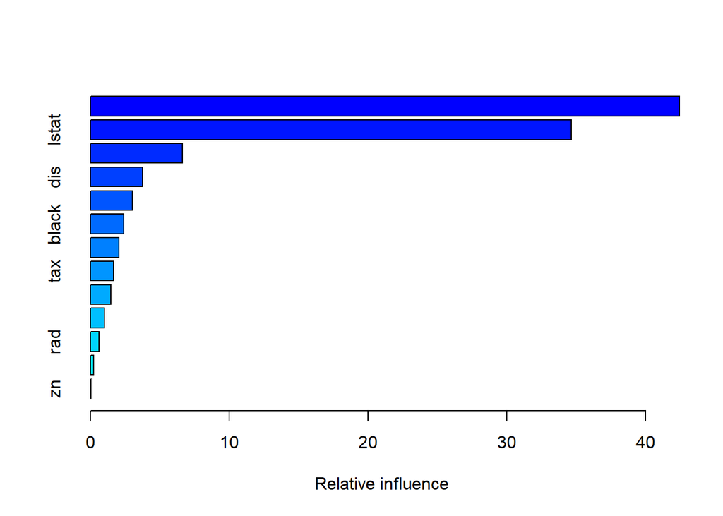

```
##             var     rel.inf
## rm           rm 42.41867339
## lstat     lstat 34.63198115
## crim       crim  6.64661294
## dis         dis  3.77963736
## nox         nox  3.02837237
## black     black  2.42373217
## age         age  2.03883389
## tax         tax  1.65431757
## ptratio ptratio  1.45799424
## indus     indus  0.99709703
## rad         rad  0.62357023
## chas       chas  0.24072033
## zn           zn  0.05845732
```

```r
summary(boomodel)
```

> Again, we can see that the variables ‘rm’, ‘lstat’ and ‘crim’ have the greatest influence.

## Question 17

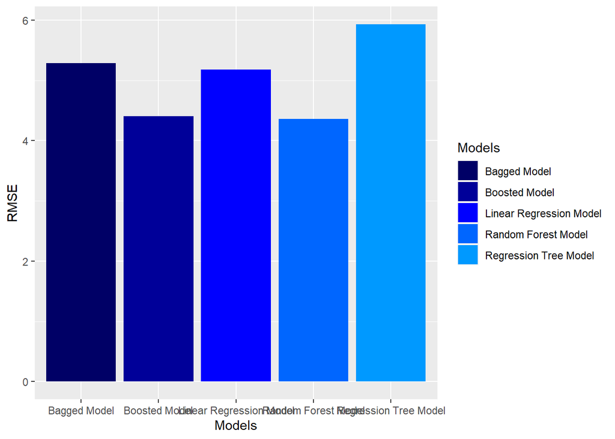

```r
df <- data.frame(Models= c("Regression Tree Model", "Linear Regression Model", "Bagged Model", "Random Forest Model", "Boosted Model"), RMSE= c(trmse, lrmse, brmse, rfrmse, boormse))

library("ggplot2")
ggplot(df, aes(x= Models, y= RMSE)) +
  geom_col(aes(fill= Models)) +
  scale_fill_manual(values= c("#000066", "#000099", "#0000FF", "#0066FF", "#0099FF"))
```

>We can see that the model with the best performance is the Random Forest Model.

# *Classification Tree*

## Question 18

```r
spamdata <- read.csv("E:/ESILV/S7/Machine Learning/PW/PW5/spam.csv")

head(spamdata)
```

```
##   spam make address  all X3d  our over remove internet order mail receive will
## 1 TRUE 0.00    0.64 0.64   0 0.32 0.00   0.00     0.00  0.00 0.00    0.00 0.64
## 2 TRUE 0.21    0.28 0.50   0 0.14 0.28   0.21     0.07  0.00 0.94    0.21 0.79
## 3 TRUE 0.06    0.00 0.71   0 1.23 0.19   0.19     0.12  0.64 0.25    0.38 0.45
## 4 TRUE 0.00    0.00 0.00   0 0.63 0.00   0.31     0.63  0.31 0.63    0.31 0.31
## 5 TRUE 0.00    0.00 0.00   0 0.63 0.00   0.31     0.63  0.31 0.63    0.31 0.31
## 6 TRUE 0.00    0.00 0.00   0 1.85 0.00   0.00     1.85  0.00 0.00    0.00 0.00
##   people report addresses free business email  you credit your font X000 money
## 1   0.00   0.00      0.00 0.32     0.00  1.29 1.93   0.00 0.96    0 0.00  0.00
## 2   0.65   0.21      0.14 0.14     0.07  0.28 3.47   0.00 1.59    0 0.43  0.43
## 3   0.12   0.00      1.75 0.06     0.06  1.03 1.36   0.32 0.51    0 1.16  0.06
## 4   0.31   0.00      0.00 0.31     0.00  0.00 3.18   0.00 0.31    0 0.00  0.00
## 5   0.31   0.00      0.00 0.31     0.00  0.00 3.18   0.00 0.31    0 0.00  0.00
## 6   0.00   0.00      0.00 0.00     0.00  0.00 0.00   0.00 0.00    0 0.00  0.00
##   hp hpl george X650 lab labs telnet X857 data X415 X85 technology X1999 parts
```

[output cut: 20 more lines]

```r
set.seed(123)

sample_size <- sample(1:nrow(spamdata), size= round(0.8*nrow(spamdata)), replace= FALSE)

training_set <- spamdata[sample_size,]
test_set <- spamdata[-sample_size,]

dim(training_set)
```

```
## [1] 3681   58
```

```r
dim(test_set)
```

```
## [1] 920  58
```

```r
Accuracy <- function(v1, v2){
  pred <- ifelse(v1 > 0.5, "TRUE", "FALSE")

  accuracy <- mean(pred == v2)
  return(accuracy)
}
```

### *Logistic Regression Model*

```r
logmodel <- glm(spam~., data= training_set, family= binomial)
logpre <- predict(logmodel, test_set, type= "response")

logacc <- Accuracy(logpre, test_set$spam)
logacc
```

```
## [1] 0.925
```

### *Simple Classification Tree Model*

```r
library("rpart")

tmodel <- rpart(spam~., data= training_set)

tpre <- predict(tmodel, test_set, type= "vector")

tacc <- Accuracy(tpre, test_set$spam)
tacc
```

```
## [1] 0.901087
```

### *Bagged Model*

```r
library("ipred")

btraining_set <- training_set
btraining_set$spam <- ifelse(btraining_set$spam == "TRUE", 1, 0)

bmodel <- bagging(spam~., data= btraining_set, nbagg = 500, coob= TRUE)

bpre <- predict(bmodel, test_set, type= "response")

bacc <- Accuracy(bpre, test_set$spam)
bacc
```

```
## [1] 0.9130435
```

### *Random Forest Model*

```r
library("randomForest")

rfmodel <- randomForest(spam~., data= training_set, importance= TRUE)
rfpre <- predict(rfmodel, test_set, type= "response")

rfacc <- Accuracy(rfpre, test_set$spam)
rfacc
```

```
## [1] 0.9467391
```

### *Boosted models*

```r
library("gbm")

boomodel <- gbm(spam~., data= training_set, distribution= "gaussian", n.trees=500)

boopre <- predict(boomodel, test_set, type= "response")
```

```
## Using 500 trees...
```

```r
booacc <- Accuracy(boopre, test_set$spam)
booacc
```

```
## [1] 0.9402174
```

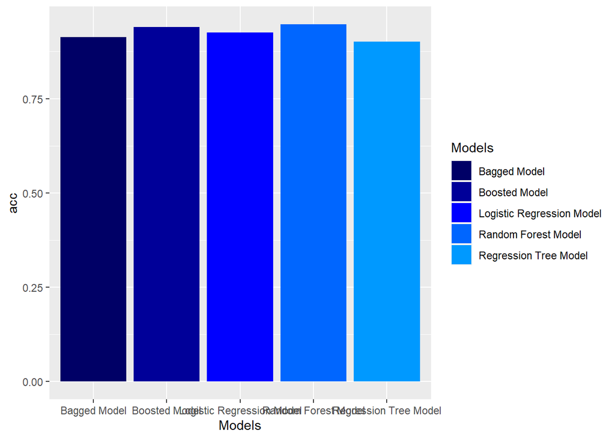

```r
df <- data.frame(Models= c("Logistic Regression Model", "Regression Tree Model", "Bagged Model", "Random Forest Model", "Boosted Model"),
                 acc= c(logacc, tacc, bacc, rfacc, booacc))

library("ggplot2")

ggplot(df, aes(x= Models, y= acc)) +
  geom_col(aes(fill= Models)) +
  scale_fill_manual(values= c("#000066", "#000099", "#0000FF", "#0066FF", "#0099FF"))
```

>We can see that the model which has the best accuracy is: Random Forest Model. The ranking of the models with the best accuracy is: - Random Forest - Boosted Model - Logistic Regression Model - Bagged Model - Regression Tree Model

# *Tuning Tree*

## Question 19

```r
#Automatic Grid
library("caret")
```

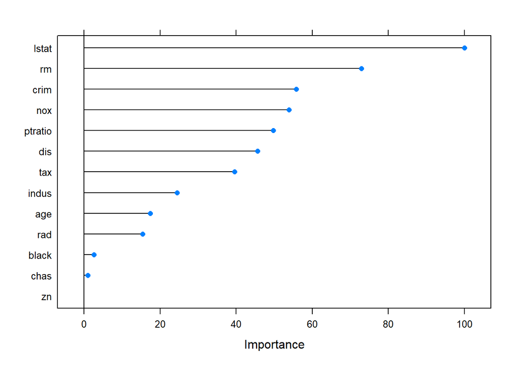

```r
library("rpart")

control <- trainControl(method = "cv", number = 10)

btune <- train(medv~ ., data = Boston, method = "treebag",
        trControl = control)

plot(varImp(btune))
```

```r
bootune <- train(medv~ ., data = Boston, method = "gbm",
        trControl = control)
```

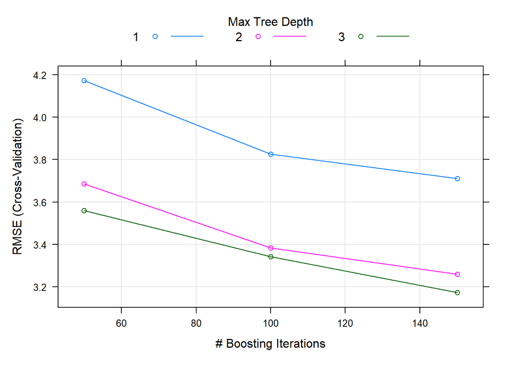

```r
plot(bootune)
```

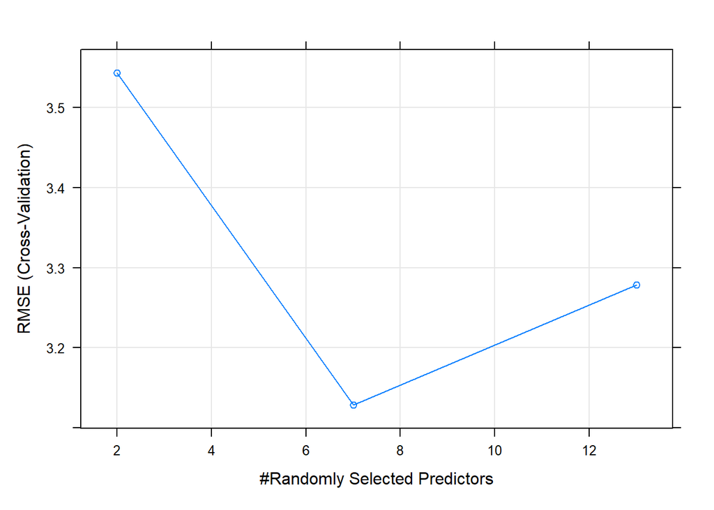

```r
rftune <- train(medv~ ., data = Boston, method = "rf",
        trControl = control)

plot(rftune)
```